# Notes on statistical analysis

Katerina Symiakaki

Created on 13/12/2022. Last update on 05/01/2023.

Here I plan to write what I try and don’t try for the analysis of data from the experiment in Sweden.

Data produced from microscope counts. Magnification always 1000x. Count to about 100 cells total. Count only what is inside the square area in the ocular lens. Sides of the square are 100 microns.

The volume of 1 field of view is (in mL):

```r
V = 10 * (0.1 * 0.1) / (pi * (21/2)^2)
```

Load data  
*The range specified includes ALL 0.8 samples. It will fill up as more get analyzed, but for now just filter the area you need*

```r
master.dat <- read_xlsx("SITES_microscope_data_sheet.xlsx",
                        sheet = 2,
                        range = "A1:T217",
                        col_names = T)

# for some reason all number columns are characters. Let's convert that
master.dat[,14:20] <- lapply(master.dat[,14:20], as.numeric)
master.dat$Mesocosm <- as.factor(master.dat$Mesocosm)
master.dat$Mes_ID <- as.factor(master.dat$Mes_ID)

# some basic cleaning - wrangling
partial_dat <- master.dat %>%
                select(-c(Date,Date_analysed,Box,Comments,`Photos/ImageJ`)) %>%
                mutate(
#maybe I need to do more factor stuff with other columns
                Treatment = fct_relevel(Treatment, c("C","D","I","E")),
                Tot_cells = HF_total + PF + MF,
# calculate ingestion rates - NOW IT'S COUNTS
                Mir = FLBinMF_total / (MF * 0.5),
                Hir = FLBinHF_total / (HFwFLB * 0.5),
                Vol = Fields_counted * V,
# calculate abundances
                aHF = as.integer(as.character(HF_total/Vol)),
                aMF = MF/Vol,
                aPF = PF/Vol) %>%

# filter for Incubation 2 and T30

                filter(Incubation == 2 & Time_point == "Tend") %>%
                drop_na()
```

### EDA

do some stats  
Histogram with the distribution of counts

```r
summary(partial_dat)
```

```
##        id           Sample            Incubation Treatment    Mesocosm
##  Min.   :181.0   Length:36          Min.   :2    C:9       C1     : 3
##  1st Qu.:189.8   Class :character   1st Qu.:2    D:9       C2     : 3
##  Median :198.5   Mode  :character   Median :2    I:9       C4     : 3
##  Mean   :198.5                      Mean   :2    E:9       D2     : 3
##  3rd Qu.:207.2                      3rd Qu.:2              D3     : 3
##  Max.   :216.0                      Max.   :2              D4     : 3
##                                                            (Other):18
##      Mes_ID    Replicate          Time_point           HF_total
##  1      : 3   Length:36          Length:36          Min.   :34.00
##  3      : 3   Class :character   Class :character   1st Qu.:46.25
##  4      : 3   Mode  :character   Mode  :character   Median :51.50
##  6      : 3                                         Mean   :52.92
##  7      : 3                                         3rd Qu.:59.25
##  8      : 3                                         Max.   :77.00
##  (Other):18
##      HFwFLB             PF              MF         FLBinHF_total
##  Min.   : 2.000   Min.   :22.00   Min.   : 1.000   Min.   : 2.000
##  1st Qu.: 4.000   1st Qu.:37.00   1st Qu.: 5.000   1st Qu.: 5.000
##  Median : 6.000   Median :42.50   Median : 8.000   Median : 8.000
##  Mean   : 6.722   Mean   :43.17   Mean   : 7.611   Mean   : 8.944
##  3rd Qu.: 8.250   3rd Qu.:50.00   3rd Qu.:10.000   3rd Qu.:11.250
##  Max.   :18.000   Max.   :67.00   Max.   :17.000   Max.   :27.000
##
##  FLBinMF_total   Fields_counted    Tot_cells          Mir
##  Min.   : 2.00   Min.   : 70.0   Min.   :100.0   Min.   :2.000
##  1st Qu.: 7.00   1st Qu.:120.0   1st Qu.:100.0   1st Qu.:2.433
##  Median :10.00   Median :155.5   Median :101.0   Median :3.000
##  Mean   :11.25   Mean   :150.5   Mean   :103.7   Mean   :2.989
##  3rd Qu.:14.25   3rd Qu.:182.0   3rd Qu.:103.0   3rd Qu.:3.414
##  Max.   :32.00   Max.   :234.0   Max.   :128.0   Max.   :4.000
##
##       Hir             Vol               aHF              aMF
##  Min.   :2.000   Min.   :0.02021   Min.   : 695.0   Min.   : 28.39
##  1st Qu.:2.277   1st Qu.:0.03465   1st Qu.: 911.5   1st Qu.:122.81
##  Median :2.500   Median :0.04490   Median :1210.5   Median :164.50
##  Mean   :2.679   Mean   :0.04345   Mean   :1331.0   Mean   :185.95
##  3rd Qu.:3.000   3rd Qu.:0.05255   3rd Qu.:1641.0   3rd Qu.:254.43
##  Max.   :5.600   Max.   :0.06756   Max.   :2511.0   Max.   :377.22
##
##       aPF
##  Min.   : 448.2
##  1st Qu.: 816.7
##  Median :1065.2
##  Mean   :1065.2
##  3rd Qu.:1263.4
##  Max.   :2325.6
##
```

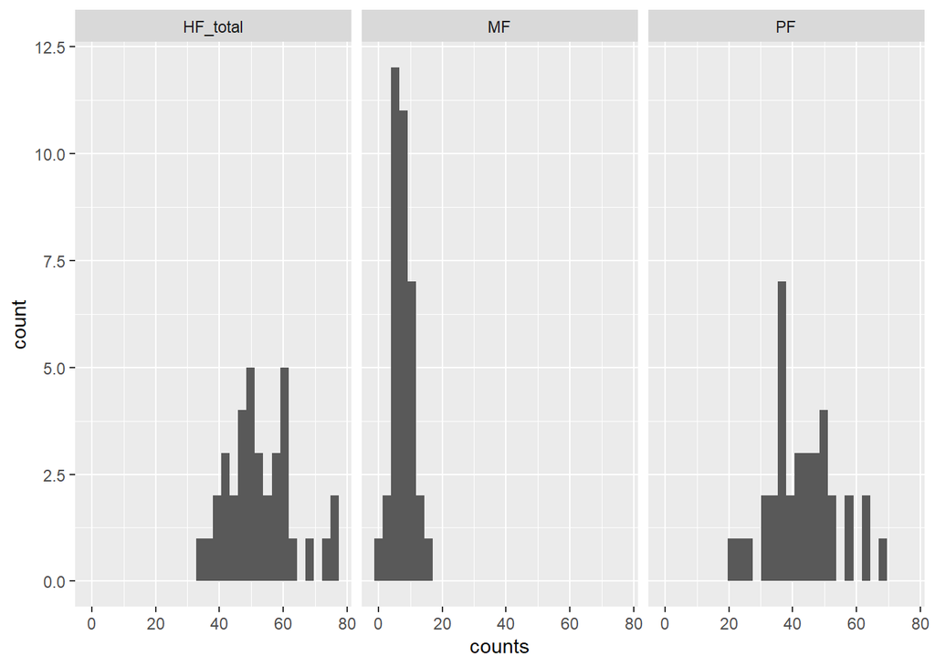

```r
partial_dat %>%
  pivot_longer(cols = c(HF_total, PF, MF), names_to = "group", values_to = "counts") %>%
  ggplot(., aes(x = counts)) +
  geom_histogram() +
  facet_grid(cols = vars(group))
```

```r
partial_dat %>%
  pivot_longer(cols = c(aHF, aPF, aMF), names_to = "group", values_to = "abundance") %>%
  ggplot(., aes(x = abundance)) +
  geom_histogram() +
  facet_grid(cols = vars(group))
```

[output not shown]

```r
mean.mes <- partial_dat %>%
  pivot_longer(cols = c(aHF, aPF, aMF), names_to = "group", values_to = "abundance") %>%
  group_by(
    # Incubation,
    Treatment,
    Mes_ID,
    group) %>%
  summarise(mean = mean(abundance),
            sd = sd(abundance))

mean.trt <- partial_dat %>%
  pivot_longer(cols = c(aHF, aPF, aMF), names_to = "group", values_to = "abundance") %>%
  group_by(
    # Incubation,
    Treatment,
    group) %>%
  summarise(mean = mean(abundance),
            sd = sd(abundance))

ggplot(mean.trt, aes(x=Treatment, y=mean)) +
  geom_point()+
  geom_point(mean.mes, aes(x=mean.mes$Treatment, y=mean.mes$mean, fill=mean.mes$Mes_ID))+
  geom_errorbar(aes(ymin=mean-sd, ymax=mean+sd),
                width=.2,
                position = position_dodge(0.05)) +
    facet_grid(cols = vars(group))
```

[output not shown]

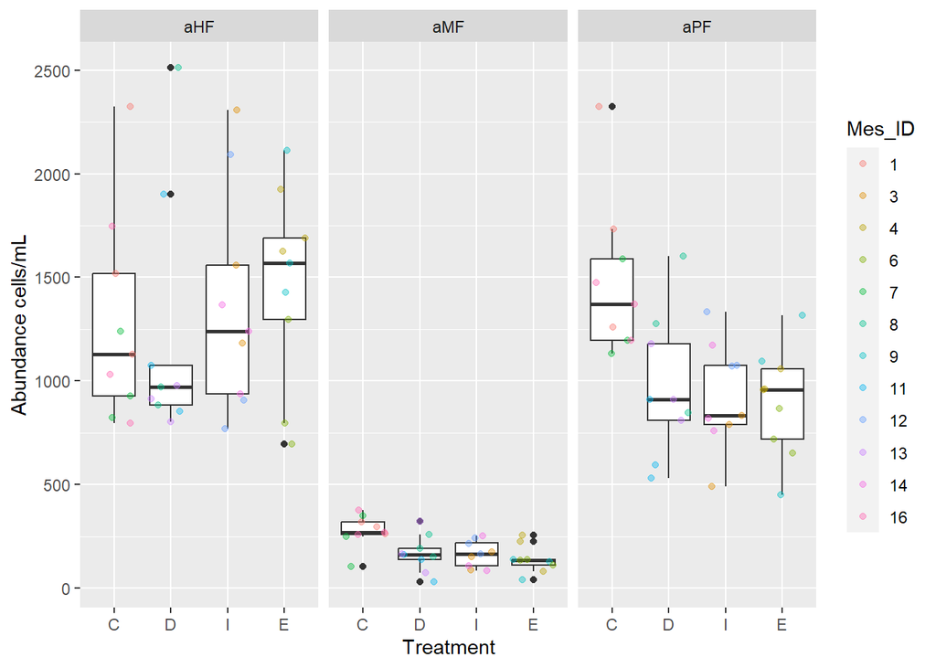

```r
partial_dat %>%
  pivot_longer(cols = c(aHF, aPF, aMF), names_to = "group", values_to = "abundance") %>%
  ggplot(., aes(x = Treatment, y = abundance)) +
  geom_boxplot() +
  geom_point(aes(x = Treatment, y = abundance, colour = Mes_ID),
             position = "jitter",
             alpha = 0.4,
             # shape = 1, stroke = 0.7
             ) +
  ylab("Abundance cells/mL")+
  facet_grid(cols = vars(group))
```

### Serious stats

GLMM

#### Heterotrophic

```r
library(glmmTMB)
library(ggeffects)
library(performance)
library(DHARMa)
hm = glmmTMB(aHF ~ 1
            + Treatment
            + (1|Mesocosm),
            # offset = Vol,
            family = poisson(),
            data = partial_dat);summary(hm)
```

```
##  Family: poisson  ( log )
## Formula:          aHF ~ 1 + Treatment + (1 | Mesocosm)
## Data: partial_dat
##
##      AIC      BIC   logLik deviance df.resid
##   4540.1   4548.0  -2265.1   4530.1       31
##
## Random effects:
##
## Conditional model:
##  Groups   Name        Variance Std.Dev.
##  Mesocosm (Intercept) 0.04844  0.2201
## Number of obs: 36, groups:  Mesocosm, 12
##
## Conditional model:
##             Estimate Std. Error z value Pr(>|z|)
## (Intercept)  7.13352    0.12743   55.98   <2e-16 ***
## TreatmentD  -0.05553    0.18023   -0.31    0.758
## TreatmentI   0.07946    0.18019    0.44    0.659
## TreatmentE   0.11320    0.18019    0.63    0.530
## ---
## Signif. codes:  0 '***' 0.001 '**' 0.01 '*' 0.05 '.' 0.1 ' ' 1
```

```r
check_model(hm) # why error????
```

```
## `check_outliers()` does not yet support models of class `glmmTMB`.
```

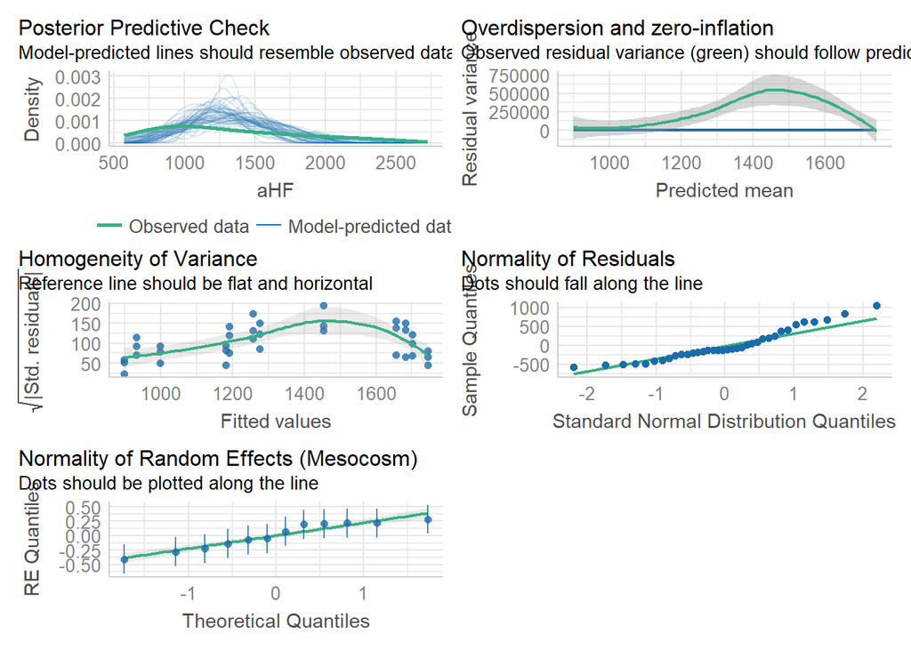

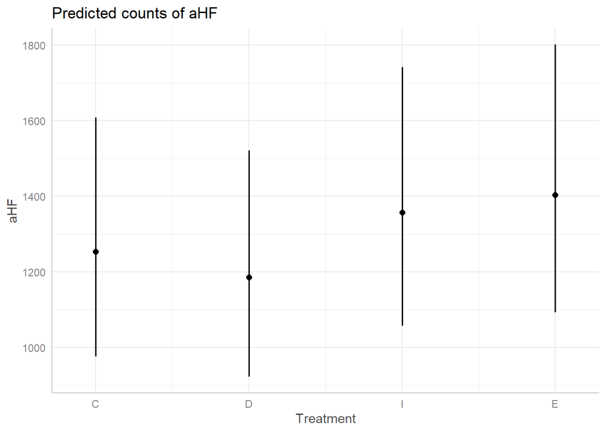

```r
h.pred <- ggpredict(hm, terms = c("Treatment"))

plot(h.pred)
```

```r
 # simulateResiduals(fittedModel = hm, plot = T)
```

*Something else to try*  
influence measures  
quantify the effects of particular observations, or groups of observations, on the results of a statistical model

```r
source(system.file("other_methods","influence_mixed.R", package="glmmTMB"))
# hm_inf_time <- system.time(
hm_inf <- influence_mixed(hm, groups="Mesocosm")
```

```
## using a cluster of 2 cores
```

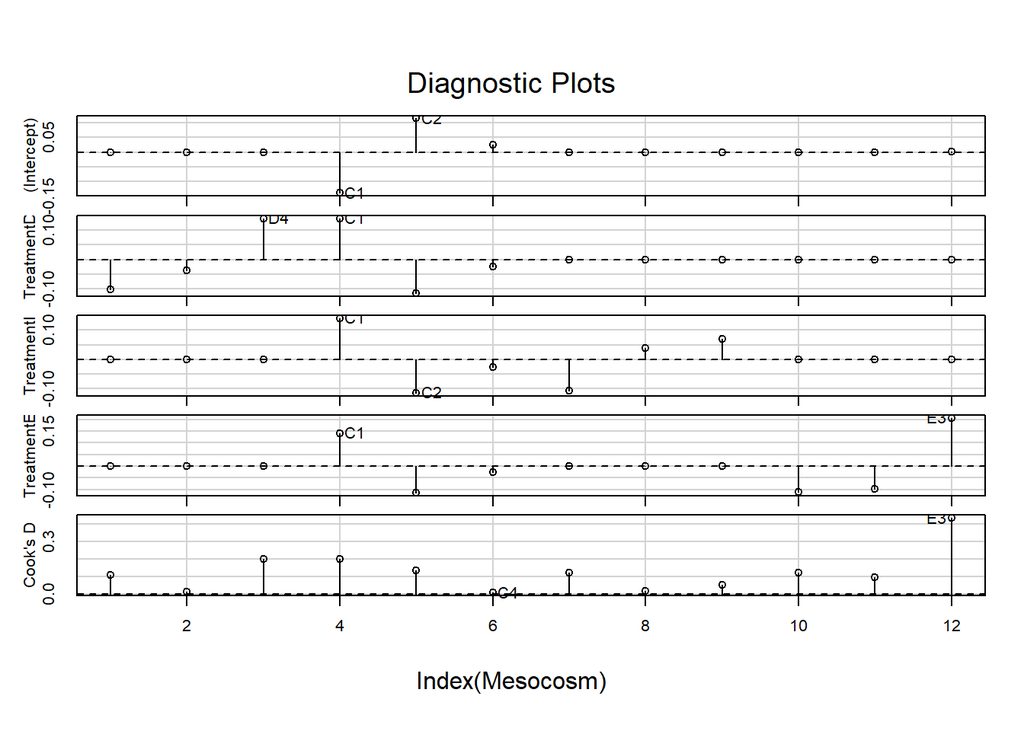

```r
# )

car::infIndexPlot(hm_inf)
```

#### Mixotrophic

```r
mm = glmmTMB(aMF ~ 1
            + Treatment
            + (1|Mesocosm),
            # offset = log(Fields_counted),
            family = poisson(),
            data = partial_dat);summary(mm)
```

```
##  Family: poisson  ( log )
## Formula:          aMF ~ 1 + Treatment + (1 | Mesocosm)
## Data: partial_dat
##
##      AIC      BIC   logLik deviance df.resid
##   1132.3   1140.2   -561.1   1122.3       31
##
## Random effects:
##
## Conditional model:
##  Groups   Name        Variance Std.Dev.
##  Mesocosm (Intercept) 0.04286  0.207
## Number of obs: 36, groups:  Mesocosm, 12
##
## Conditional model:
##             Estimate Std. Error z value Pr(>|z|)
## (Intercept)   5.6130     0.1212   46.30  < 2e-16 ***
## TreatmentD   -0.5373     0.1723   -3.12  0.00182 **
## TreatmentI   -0.5263     0.1723   -3.06  0.00225 **
## TreatmentE   -0.7138     0.1727   -4.13 3.59e-05 ***
## ---
## Signif. codes:  0 '***' 0.001 '**' 0.01 '*' 0.05 '.' 0.1 ' ' 1
```

```r
check_model(mm) # why error????
```

```
## `check_outliers()` does not yet support models of class `glmmTMB`.
```

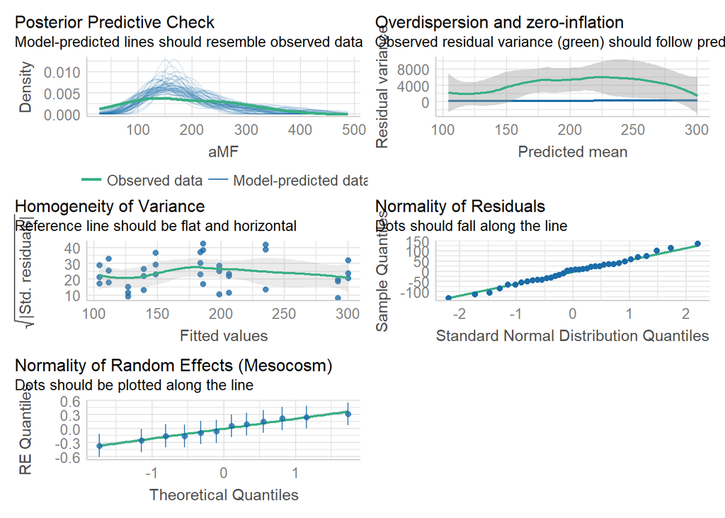

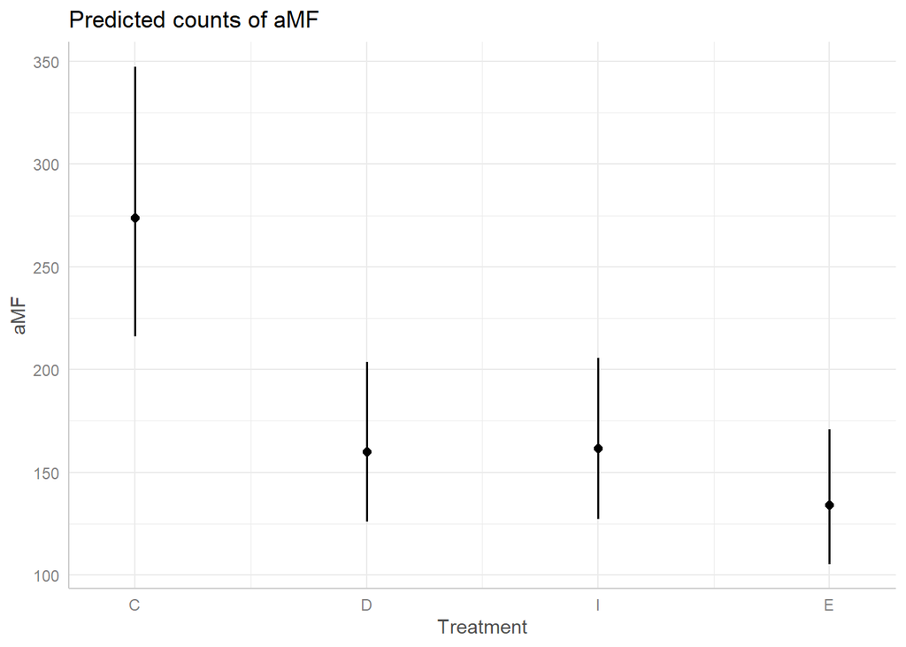

```r
plot(ggpredict(mm, terms = c("Treatment")))
```

```r
# plot(simulateResiduals(fittedModel = mm))
```

influence measures

```r
source(system.file("other_methods","influence_mixed.R", package="glmmTMB"))
# hm_inf_time <- system.time(
mm_inf <- influence_mixed(mm, groups="Mesocosm")
```

```
## using a cluster of 2 cores
```

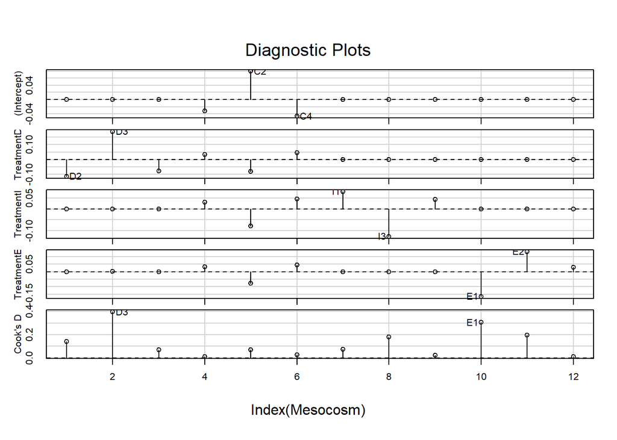

```r
# )

car::infIndexPlot(mm_inf)
```

#### Phototrophic

```r
pm = glmmTMB(aPF ~ 1
            + Treatment
            + (1|Mesocosm),
            # offset = log(Fields_counted),
            family = poisson(),
            data = partial_dat);summary(pm)
```

```
##  Family: poisson  ( log )
## Formula:          aPF ~ 1 + Treatment + (1 | Mesocosm)
## Data: partial_dat
##
##      AIC      BIC   logLik deviance df.resid
##   2029.6   2037.6  -1009.8   2019.6       31
##
## Random effects:
##
## Conditional model:
##  Groups   Name        Variance Std.Dev.
##  Mesocosm (Intercept) 0.0341   0.1847
## Number of obs: 36, groups:  Mesocosm, 12
##
## Conditional model:
##             Estimate Std. Error z value Pr(>|z|)
## (Intercept)   7.2867     0.1070   68.12  < 2e-16 ***
## TreatmentD   -0.4471     0.1514   -2.95  0.00315 **
## TreatmentI   -0.4748     0.1514   -3.14  0.00172 **
## TreatmentE   -0.4959     0.1514   -3.27  0.00106 **
## ---
## Signif. codes:  0 '***' 0.001 '**' 0.01 '*' 0.05 '.' 0.1 ' ' 1
```

```r
check_model(pm) # why error????
```

```
## `check_outliers()` does not yet support models of class `glmmTMB`.
```

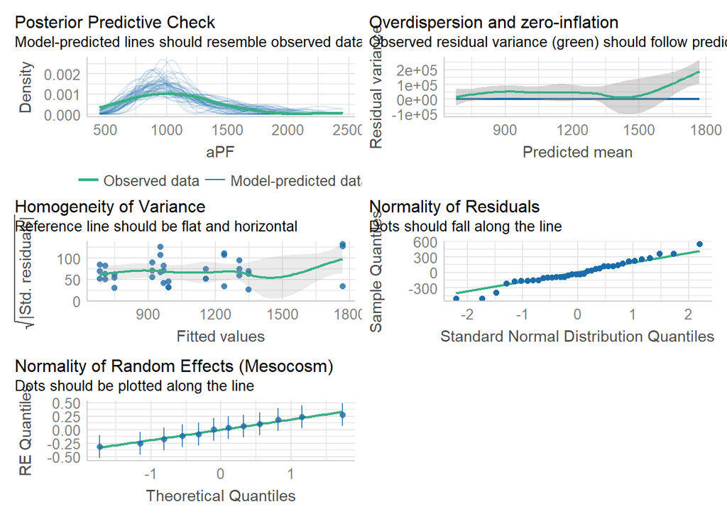

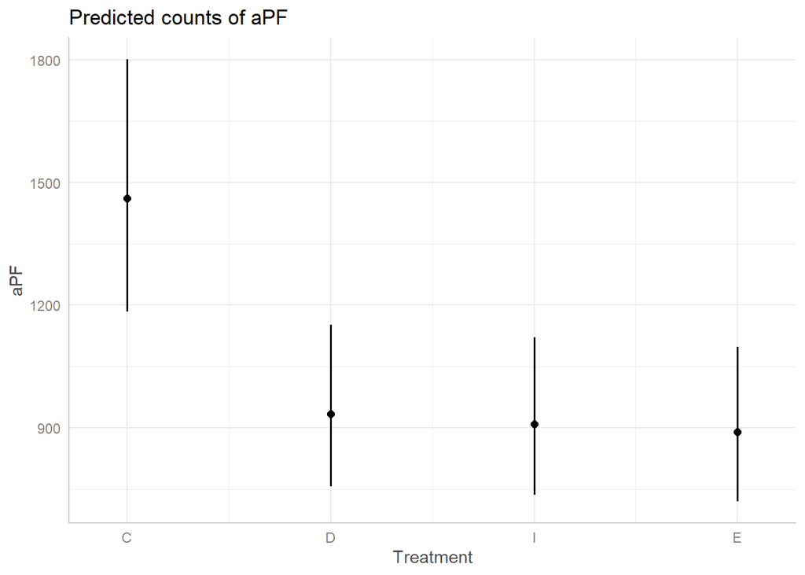

```r
plot(ggpredict(pm, terms = c("Treatment")))
```

```r
# simulateResiduals(fittedModel = pm, plot = T)
```

influence measures

```r
source(system.file("other_methods","influence_mixed.R", package="glmmTMB"))
# hm_inf_time <- system.time(
pm_inf <- influence_mixed(pm, groups="Mesocosm")
```

```
## using a cluster of 2 cores
```

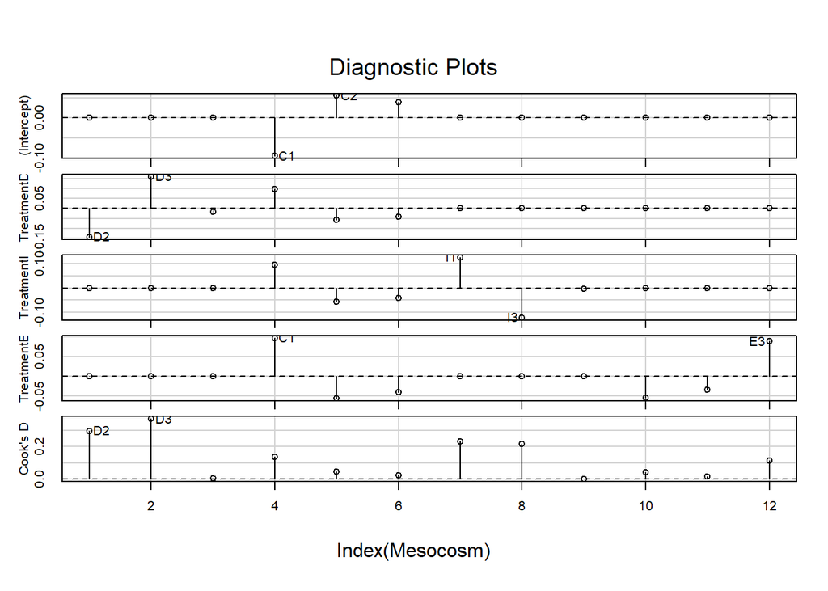

```r
# )

car::infIndexPlot(pm_inf)
```

For some reason there is a difference if I use `Mesocosm` or `Mes_ID` for the random effects for all three groups (HF-MF-PF). Results **don’t change when changing the class** (factor vs character).

1st case:

[output not shown]

2nd case:

| Groups Name | Variance | Std.Dev |
| --- | --- | --- |
| Mes_ID (Intercept) | 2.26e-09 | 4.754e-05 |

```r
library(brms)

mb = brm(bf(aHF ~ Treatment
            + (1|Mesocosm)),
            # + offset(log(Fields_counted))),
         family = gaussian(link = "log"),
         chains = 4,
         iter = 2000,
         cores = 4,
         backend = "cmdstanr",
         data = partial_dat)

pp_check(mb, ndraws = 1e2)
plot(mb)
summary(mb)



plot(conditional_effects(mb), ask = FALSE)
```

integer-gaussian > numeric-gaussian > integer-poisson